# Alpha Diversity

Load libraries

```r
library(tidyverse)
library(vegan)
library(plyr)
```

Import Tables

```r
asv <- read_csv("table.from_biom_after_rare.csv")
metadata <- read_csv("enrichment_metadata.csv")
```

Convert table so that each row is a different sample and each column is indivual asv abundances. Th pivot_longer number will vary based on how many samples are in your dataframe. The first column is ASV IDs, so we will pivot to make the table longer so that it is only 3 columns (ASV, Sample, counts) and then will pivot_wider so ASV IDs are now individual columns and the first column is sample IDs.

```r
table <- asv %>%
  pivot_longer(2:16, names_to = "Sample", values_to = "counts") %>%
  pivot_wider(names_from = "ASV ID", values_from = counts)
```

Calculate richness for each sample. Richness is a measure of alpha diversity that calculates the number of unique features in a community. Here a feature is reprentated at the ASV level, but could be calculated for different levels such as Genus, Family, Class, etc.

```r
richness<-  ddply(table,~Sample,function(x) {
   data.frame(Richness=sum(x[-1]>0))
 })
```

```r
evenness<- ddply(table,~Sample,function(x) {
         data.frame(Evenness=diversity(x[-1], index="simpson")/log(sum(x[-1]>0)))
 })
```

Calculate shannon diversity index (H) for each sample. Shannon diversity index is a measure of alpha diversity that takes into account both richness and eveness. Shannon index is the proportion of individuals of one particular feature found divided by the total number of individuals found.

```r
shannon <- ddply(table,~Sample,function(x) {
         data.frame(Shannon=diversity(x[-1], index="shannon"))
 })
```

Merge calculations into one table

```r
join <- shannon %>%
  full_join(richness) %>%
  full_join(evenness) %>%
  inner_join(metadata) %>%
  pivot_longer(2:4, names_to = "Type", values_to = "Diversity")
```

Plot tables

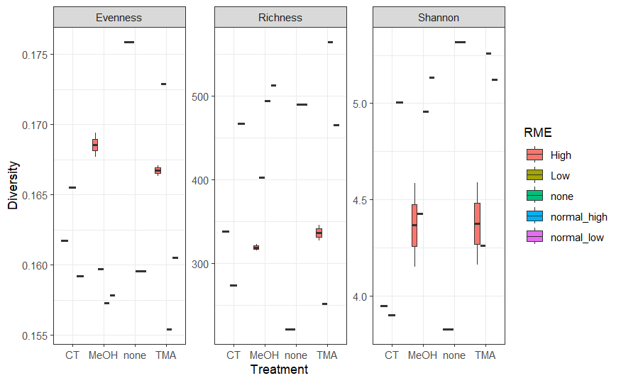

```r
plot <- ggplot(join, aes(x=Treatment, y=Diversity, fill=RME)) +
  geom_boxplot() +
  facet_wrap(~Type, scales="free")+
  theme_bw()

plot
```

```r
alpha <- shannon %>%
  full_join(richness) %>%
  full_join(evenness) %>%
  inner_join(metadata)
```

ANOVA requires a mix of one continuous quantitative dependent variable (which corresponds to the measurements to which the question relates) and one qualitative independent variable (with at least 2 levels which will determine the groups to compare). Assumptions: 1. Observations are independent 2.Sample size a) small sample sizes (less than 30 samples per group) must have normal distribution; if distribution is not normal use Kruskal-Wallis test b) large sample sizes (more than 30 samples per group) normal distribution is assumed 3. Equal variance, if variance is not equal use a Welch ANOVA

To test for normality, we must first run the ANOVA

```r
res_aov <- aov(Richness ~ Treatment*RME, data = alpha)
res_aov
```

```
Call:
   aov(formula = Richness ~ Treatment * RME, data = alpha)

Terms:
                Treatment       RME Treatment:RME Residuals
Sum of Squares    6850.03 133927.49      16870.38    212.50
Deg. of Freedom         3         4             5         2

Residual standard error: 10.30776
7 out of 20 effects not estimable
Estimated effects may be unbalanced
```

Normality can be tested in several ways both visually (histogram and QQ-plot) and more formally using a Shapiro-Wilkes test. Here we will only go over the Shapiro-Wilkes test

```r
shapiro.test(res_aov$residuals)
```

```
    Shapiro-Wilk normality test

data:  res_aov$residuals
W = 0.72729, p-value = 0.0004944
```

Homogeneity of variance can be assessed visually (using a boxplot or dotplot) or can be done with Levene’s or Bartlett’s test. We will go over Levene’s test here.

```r
library(car)

leveneTest(Shannon ~ Treatment, data = alpha)
```

```
Levene's Test for Homogeneity of Variance (center = median)
      Df F value Pr(>F)
group  3  0.9163 0.4647
      11
```

To look at results from the ANOVA

```r
res_aov <- aov(Evenness ~ Treatment*RME, data = alpha)

summary(res_aov)
```

```
              Df    Sum Sq   Mean Sq F value  Pr(>F)
Treatment      3 0.0000512 1.706e-05   20.15 0.04765 *
RME            4 0.0003487 8.718e-05  102.98 0.00964 **
Treatment:RME  5 0.0001130 2.259e-05   26.69 0.03651 *
Residuals      2 0.0000017 8.500e-07
---
Signif. codes:  0 ‘***’ 0.001 ‘**’ 0.01 ‘*’ 0.05 ‘.’ 0.1 ‘ ’ 1
```

```r
tukey<-TukeyHSD(res_aov)

tukey
```

```
  Tukey multiple comparisons of means
    95% family-wise confidence level

Fit: aov(formula = Evenness ~ Treatment * RME, data = alpha)

$Treatment
                   diff           lwr         upr     p adj
MeOH-CT    0.0002427054 -4.413232e-03 0.004898643 0.9799926
none-CT    0.0055895258 -2.303957e-04 0.011409447 0.0540119
TMA-CT     0.0023003351 -2.355602e-03 0.006956272 0.1808510
none-MeOH  0.0053468204  1.277422e-05 0.010680867 0.0497716
TMA-MeOH   0.0020576297 -1.974530e-03 0.006089790 0.1711920
TMA-none  -0.0032891907 -8.623237e-03 0.002044855 0.1229309

$RME
                               diff          lwr           upr     p adj
Low-High               -0.001057766 -0.006063686  0.0039481536 0.5970447
none-High              -0.012260121 -0.019906790 -0.0046134521 0.0199534
normal_high-High       -0.009806619 -0.014812539 -0.0048006995 0.0136326
normal_low-High        -0.008336458 -0.014116796 -0.0025561196 0.0245378
none-Low               -0.011202355 -0.019376988 -0.0030277218 0.0271170
normal_high-Low        -0.008748853 -0.014529191 -0.0029685148 0.0223268
normal_low-Low         -0.007278692 -0.013741306 -0.0008160769 0.0397410
normal_high-none        0.002453502 -0.005721131  0.0106281344 0.3958339
normal_low-none         0.003923663 -0.004746845  0.0125941705 0.2119822
normal_low-normal_high  0.001470161 -0.004992453  0.0079327762 0.5537389

$`Treatment:RME`
                                           diff          lwr           upr     p adj
MeOH:High-CT:High                  0.0068042974 -0.006569168  2.017776e-02 0.1776660
none:High-CT:High                  0.0141530657 -0.001289282  2.959541e-02 0.0589627
TMA:High-CT:High                   0.0049777077 -0.008395758  1.835117e-02 0.3029411
CT:Low-CT:High                     0.0037643254 -0.011678022  1.920667e-02 0.5564153
MeOH:Low-CT:High                  -0.0020167354 -0.017459083  1.342561e-02 0.9178318
none:Low-CT:High                             NA           NA            NA        NA
TMA:Low-CT:High                    0.0111428863 -0.004299461  2.658523e-02 0.0933603
CT:none-CT:High                              NA           NA            NA        NA
MeOH:none-CT:High                            NA           NA            NA        NA
none:none-CT:High                 -0.0021636836 -0.017606031  1.327866e-02 0.8909939
TMA:none-CT:High                             NA           NA            NA        NA
```

[output cut: 164 more lines]

```
TMA:normal_high-none:normal_high             NA           NA            NA        NA
CT:normal_low-none:normal_high               NA           NA            NA        NA
MeOH:normal_low-none:normal_high             NA           NA            NA        NA
none:normal_low-none:normal_high             NA           NA            NA        NA
TMA:normal_low-none:normal_high              NA           NA            NA        NA
CT:normal_low-TMA:normal_high                NA           NA            NA        NA
MeOH:normal_low-TMA:normal_high    0.0024547475 -0.012987600  1.789710e-02 0.8310782
none:normal_low-TMA:normal_high              NA           NA            NA        NA
TMA:normal_low-TMA:normal_high     0.0051020566 -0.010340291  2.054440e-02 0.3653788
MeOH:normal_low-CT:normal_low                NA           NA            NA        NA
none:normal_low-CT:normal_low                NA           NA            NA        NA
TMA:normal_low-CT:normal_low                 NA           NA            NA        NA
none:normal_low-MeOH:normal_low              NA           NA            NA        NA
TMA:normal_low-MeOH:normal_low     0.0026473091 -0.012795039  1.808966e-02 0.7887245
TMA:normal_low-none:normal_low               NA           NA            NA        NA
```

If normality is not met, to run a Kruskal-Wallis test

```r
kw_test <- kruskal.test(Richness ~ Treatment, data = alpha)
kw_test
```

```
    Kruskal-Wallis rank sum test

data:  Richness by Treatment
Kruskal-Wallis chi-squared = 0.635, df = 3, p-value = 0.8884
```

We will use a pairwise wilcox test for the posthoc anlaysis to determine which sites are different from each other.

```r
pairwise.wilcox.test(alpha$Richness, alpha$Treatment,
                 p.adjust.method = "BH")
```

```
    Pairwise comparisons using Wilcoxon rank sum exact test

data:  alpha$Richness and alpha$Treatment

     CT MeOH none
MeOH 1  -    -
none 1  1    -
TMA  1  1    1

P value adjustment method: BH
```